# **1 Cross Validation Techniques**

## **1.1 Introduction**

Model validation refers to the process of evaluating a model's performance on a separate dataset that wasn't used during training. The goal of validation is to ensure that the model generalizes well to unseen data, meaning it performs well not just on the training data but also on data it hasn't encountered before, which prevents **overfitting**.

**1. Validation Set**

A validation set is a portion of the dataset that is set aside specifically for this evaluation. Typically, when the dataset is sufficiently large, we can divide the dataset into a training set, a validation set, and a test set as follows.:

- **Training Set**: Used to train the model.
- **Validation Set**: Used to tune the model and evaluate its performance during training.
- **Test Set**: Used for final evaluation of the model after training is complete, to assess how well the model generalizes to completely unseen data.

**2. Cross-Validation**

However, when the dataset is not sufficient, splitting the data into the three parts mentioned above will result in a very small training set. The size of the training set determines the model's training effectiveness, so when the dataset is not large enough, the method described above is not ideal. Therefore, when the dataset is not large enough, the method of cross-validation is proposed to make the best use of the limited dataset for comprehensive training, validation, and evaluation of the model. And also prevents overfitting.

Cross-validation is a technique where the data is split into multiple subsets (or folds). The model is trained on some folds and validated on others, rotating through all folds. This made the model’s performance more reliable by ensuring that all data points can be used for both training and validation.

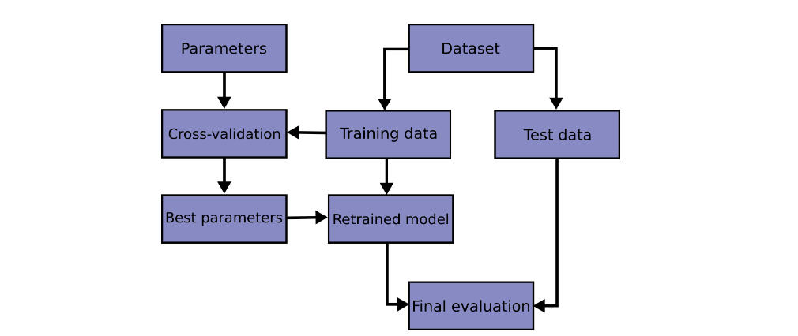

**3. Hyperparameter Tuning**

Validation is also important for hyperparameter tuning. The model's hyperparameters (e.g., learning rate, number of layers, regularization strength) are often adjusted based on validation performance. This helps prevent overfitting, where the model might perform well on the training data but poorly on new data.

**4. Performance Metrics**

During validation, various performance metrics (e.g., accuracy, precision, recall, F1-score, etc.) are used to quantify how well the model is performing.

In summary, validation is a crucial step in training machine learning models to assess their generalization ability and avoid overfitting.

## **1.2 K-fold Cross Validation**

**How it works:**

The dataset is randomly split into **k** equally sized (or nearly equal) subsets or folds. The model is trained **k** times, each time using **k-1** folds for training and the remaining fold for validation. Each fold gets to be the validation set once.

**Example:**

In 5-fold cross-validation, the dataset is divided into 5 parts. The model will train 5 times, each time using 4 parts for training and 1 part for validation. The final performance metric is the average of the metrics calculated on each fold.

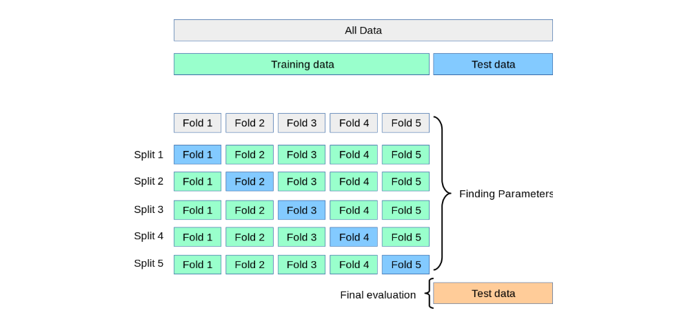

Here we modify the example in chapter4 by using a cross validation method.

```python
import numpy as np
import pandas as pd
from sklearn.model_selection import StratifiedKFold, KFold
from sklearn.metrics import r2_score
from sklearn.metrics import accuracy_score
!pip install -q rdkit-pypi
from rdkit import Chem
from rdkit.Chem import AllChem, DataStructs
from sklearn.ensemble import RandomForestRegressor, RandomForestClassifier
from sklearn.model_selection import train_test_split
from sklearn.model_selection import cross_validate
from sklearn.model_selection import cross_val_score
!pip install -q scikit-optimize
```

```
   ━━━━━━━━━━━━━━━━━━━━━━━━━━━━━━━━━━━━━━━━ 29.4/29.4 MB 31.7 MB/s eta 0:00:00
   ━━━━━━━━━━━━━━━━━━━━━━━━━━━━━━━━━━━━━━━━ 107.8/107.8 kB 6.3 MB/s eta 0:00:00
```

```python
data = pd.read_csv("https://dp-public.oss-cn-beijing.aliyuncs.com/community/hERG.csv")
data_reduced = data[0:1000]
print(data_reduced) # reduce the dataset to reduced the training time
```

[output not shown]

```python
# obtain the X and Y

# convert the 'SMILES' into a list
smiles_list = data_reduced['SMILES'].tolist()
# define a for loop to convert all smiles into morgan fingerprint
morgan_fps = []
for smiles in smiles_list:
    mol = Chem.MolFromSmiles(smiles)
    if mol:
        fp = AllChem.GetMorganFingerprintAsBitVect(mol, 2, nBits=2048)
        arr = np.zeros((1,))  # Initialize a NumPy array
        DataStructs.ConvertToNumpyArray(fp, arr)  # convert the computed fp to array
        morgan_fps.append(arr)  # Add arr to our morgan_fps

# get the X and Y
X = pd.DataFrame(morgan_fps) # use the Fingerprint as the input features
Y = data_reduced['pIC50']

print(X.shape)
print(Y.shape)

Y = np.ravel(Y) # convert Y to 1D array
```

```
(1000, 2048)
(1000,)
```

We can simply use **cross_val_score** function to perform the cross validation

```python
# initialize a Random Forest Regressor
rf = RandomForestRegressor(n_estimators=100, random_state=42)

# initialize a K-fold cross validation
kfold = KFold(n_splits=5, shuffle=True, random_state=42) # Shuffle the data order to ensure even distribution of data for each fold

# perform the cross validation and check the scores in each fold
scores = cross_val_score(rf, X, Y, cv=kfold, scoring='r2')

print(scores) # scores for all 5 folds
print(scores.mean()) # mean scores
```

[output not shown]

Or we can use **cross_validate** function to perform the cross validation

```python
scores = cross_validate(rf, X, Y, cv=kfold, scoring='r2')
scores
```

[output not shown]

Or we can use **split** function to manually examine each fold

```python
# Initialize KFold cross-validation with 5 folds
kf = KFold(n_splits=5, shuffle=True, random_state=42)

# List to store the R2 for each fold
fold_r2 = []

# Perform K-Fold Cross-Validation
for train_index, test_index in kf.split(X):
    # Split the data into training and testing based on the current fold
    X_train, X_test = X.iloc[train_index], X.iloc[test_index]  # Use .iloc for Pandas DataFrame
    y_train, y_test = Y[train_index], Y[test_index]

    # Initialize the RF model
    model = RandomForestRegressor(n_estimators=100, random_state=32)

    # Train the model on the training set
    model.fit(X_train, y_train)

    # Predict on the test set
    y_pred = model.predict(X_test)

    # Calculate r2 for this fold
    r2 = r2_score(y_test,y_pred) # R Square

    # Append the r2 to the list
    fold_r2.append(r2)

    print(f"Fold R Square: {r2:.4f}")

# Calculate the average accuracy across all folds
average_r2 = np.mean(fold_r2)
print(f"\nAverage accuracy across 5-folds: {average_r2:.4f}")
```

[output not shown]

### **Stratified K-Fold**

Stratified K-Fold Cross-Validation is a variation of k-fold cross-validation where the dataset is split such that each fold has the same proportion of each class as the entire dataset.

This is particularly useful when dealing with **imbalanced** classes, where one class might have a significantly larger number of samples than the others. Stratified K-Fold ensures that each fold has a representative distribution of classes.

It is important to remember **Stratified K-Fold Cross-Validation** can only be used in classification tasks, since its idea is to balance the numbers of samples for each class in one fold.

```python
# let's use the iris example in chapter4, this is a classification task
from sklearn.datasets import load_iris

# Load a sample dataset (Iris dataset)
data = load_iris()
X = data.data  # Features
y = data.target  # Labels

# Number of folds for cross-validation
k = 5

# Initialize StratifiedKFold cross-validation with 5 folds
skf = StratifiedKFold(n_splits=k, shuffle=True, random_state=42)

# List to store the accuracy for each fold
fold_accuracies = []

# Perform Stratified K-Fold Cross-Validation
for train_index, test_index in skf.split(X, y):
    # Split the data into training and testing based on the current fold
    X_train, X_test = X[train_index], X[test_index]
    y_train, y_test = y[train_index], y[test_index]

    # Initialize the classifier (Logistic Regression)
    model = RandomForestClassifier(n_estimators=100)

    # Train the model on the training set
    model.fit(X_train, y_train)

    # Predict on the test set
    y_pred = model.predict(X_test)

    # Calculate accuracy for this fold
    accuracy = accuracy_score(y_test, y_pred)

    # Append the accuracy to the list
    fold_accuracies.append(accuracy)

    print(f"Fold accuracy: {accuracy:.4f}")

# Calculate the average accuracy across all folds
average_accuracy = np.mean(fold_accuracies)
print(f"\nAverage accuracy across 5-folds: {average_accuracy:.4f}")
```

[output not shown]

Or we can just use the **cross_validate** function

```python
scores = cross_validate(model, X, y, cv=skf, scoring='f1_macro')
scores
```

[output not shown]

## **1.3. Leave-one-out Cross Validation**

In **Leave-one-out Cross Validation(LOO-CV)**, the number of folds is equal to the number of data points. For each iteration, one data point is used for validation, and the remaining data points are used for training. The model is trained as many times as there are data points.

**Advantage:**

Maximizes the use of the available data for training in each iteration, so you get the most out of your dataset.

**Disadvantage:**

Computationally expensive, especially for large datasets, as the model has to be trained once for every single data point.

```python
from sklearn.model_selection import LeaveOneOut
from sklearn.datasets import load_iris

# Load a sample dataset (Iris dataset)
data = load_iris()
X = data.data
y = data.target

# Initialize the LeaveOneOut cross-validation
loo = LeaveOneOut()

# Initialize the classifier (Logistic Regression)
classifier = RandomForestClassifier(n_estimators=100)

# Initialize a list to store the results
accuracies = []

# Loop through each train-test split generated by LOO
for train_index, test_index in loo.split(X):
    # Split the data into training and testing sets
    X_train, X_test = X[train_index], X[test_index]
    y_train, y_test = y[train_index], y[test_index]

    # Train the model
    classifier.fit(X_train, y_train)

    # Predict on the test sample
    y_pred = classifier.predict(X_test)

    # Calculate accuracy and append it to the list
    accuracy = accuracy_score(y_test, y_pred)
    accuracies.append(accuracy)

# Calculate the mean accuracy across all test samples
mean_accuracy = np.mean(accuracies)

# Print the results
print(f'Leave-One-Out Cross-Validation Accuracy: {mean_accuracy:.4f}')
```

[output not shown]

```python
scores = cross_validate(classifier, X, y, cv=loo, scoring='accuracy')
scores
```

[output not shown]

## **1.4 Nested Cross Validation**

Model selection without nested cross validation uses the same data to tune model parameters and evaluate model performance, having a risk of overfitting from parameter tuning to validation set. To avoid this problem, nested cross validation is introduced by separating model selection from model evaluation.

Nested CV consists of two loops:

**Outer Loop (Model Evaluation)**

- Splits the dataset into training and test sets multiple times.
- The test set is used for final model evaluation (never seen during tuning).

**Inner Loop (Hyperparameter Tuning)**

- Performs hyperparameter tuning (e.g., Grid Search, Random Search) only on the training set.
- The best model from the inner loop is selected and evaluated on the outer test set.

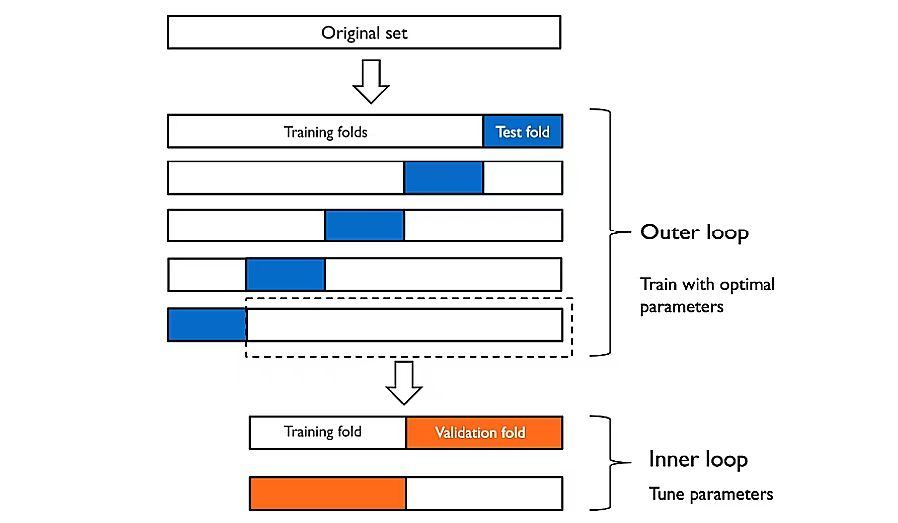

**Here is an added good example for Nested CV:**

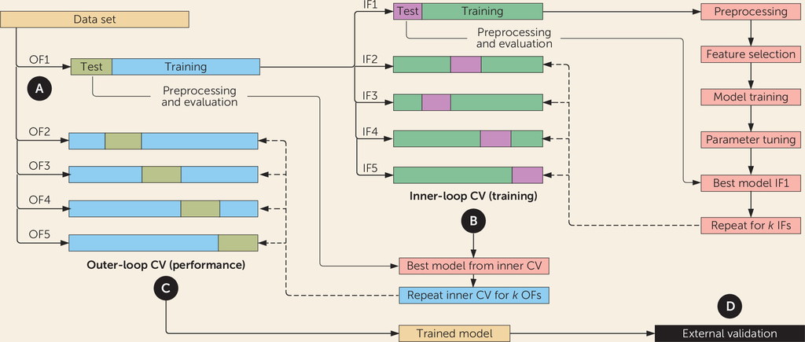

The first, but most critical, step in model construction involves splitting the cleaned data set into “training” and “test” subsets (Figure 2A). The training set is used to develop the model, while the test set is withheld to evaluate the model’s performance on unseen data. A model will have fitted parameters determined by the training data (e.g., regression coefficients), as well as adjustable hyperparameters (e.g., branch points in a decision tree). Using the same test set to optimize parameters and evaluate a model will result in overfitting, where the model describes the noise in the data set better than it does the underlying pattern between features. Errors in this step are the most common source of bias and error in the clinical machine learning literature. Failure to keep the test-set data completely independent of all subsequent steps leads to data leakage (discussed below), which may invalidate the results.

**FIGURE 2.** Development of a machine learning classification model using nested cross-validationa a Part A shows data set splitting. The data set is split into k outer folds (here, k=5). Each fold is divided into a training and a test subset. Part B shows the inner-loop cross-validation (CV). Each outer-fold training data subset is then subdivided further into k inner folds (here, k=5). The inner folds are used for model training, feature selection, and hyperparameter optimization. The best model from the inner loop of cross-validation is applied to the held-out test of the outer fold to determine model performance. Part C shows the outer-loop cross-validation. The inner loop of cross-validation is repeated for each outer loop, and results are averaged to determine performance. Part D shows external validation. Ideally, the trained model is applied to an unrelated data set (external validation) to further assess performance on unseen data. IF=inner fold; OF=outer fold.

https://psychiatryonline.org/doi/10.1176/appi.ajp.2020.20030250

Then we will go over an example of nested cv after introducing the hyperparameter tuning.

# **2 Hyperparameter Tuning**

**Hyperparameter tuning** is the process of selecting the best hyperparameters for a machine learning model to improve its performance.

Here we introduce three common methods of hyperparameter tuning:

- **Grid Search** – Tries all possible combinations of hyperparameters in a predefined set.
- **Random Search** – Randomly selects hyperparameters and evaluates the model.
- **Bayesian Optimization** – Uses probabilistic models to choose the best hyperparameters efficiently.

## **2.1 Grid Search**

**Grid Search** is a hyperparameter tuning technique used to find the optimal combination of hyperparameters for a machine learning model. It systematically explores all possible combinations of given hyperparameter values and selects the best-performing one based on a specified evaluation metric (e.g., accuracy, F1-score).

```python
from sklearn.model_selection import GridSearchCV
from sklearn.svm import SVC
from sklearn.datasets import load_iris

# load the data
iris = load_iris()
X = iris.data
y = iris.target

# SVM model
svm = SVC(kernel='linear', C=100, gamma='auto')

# define the parameter space for grid search
param_grid = {
    'C': [0.1, 1, 10, 100],
    'gamma': [1e-3, 1e-2, 1e-1, 1],
}

# define a grid search object
grid_search = GridSearchCV(svm, param_grid, cv=5, scoring='accuracy') # or we can use scoring='f1_macro'

# apply to the dataset
grid_search.fit(X, y)

# find the best parameters and its best score
print('Best parameters:', grid_search.best_params_)
print('Best score:', grid_search.best_score_)
```

[output not shown]

## **2.2 Random Search**

For **random search**, we can specify a range (or set) of values for each hyperparameter, and it randomly selects a combination of values for the hyperparameters and evaluates them. This process is repeated for a set number of iterations.

**Advantages:**

- **Faster than Grid Search:** Random Search is often much faster than Grid Search because it does not test every possible combination, but still covers a wide range of values.
- **Better for Large Hyperparameter Spaces:** If you have a large number of hyperparameters or wide ranges for each, Grid Search can become computationally expensive and time-consuming. Random Search is more efficient for exploring large spaces because it doesn't waste time trying all combinations.

```python
from sklearn.model_selection import RandomizedSearchCV
from scipy.stats import uniform, randint

# Load dataset
iris = load_iris()
X = iris.data
y = iris.target

# Define the model
svm = SVC()

# Define the parameter space
param_random = {
    'C': uniform(0.1, 10),      # Uniform distribution from 0.1 to 10
    'gamma': uniform(0.001, 1),   # Uniform distribution from 0.001 to 1
    'kernel': ['linear', 'rbf']   # Two possible kernel types
}

# Perform Randomized Search with 5-fold Cross Validation (10 iterations)
random_search = RandomizedSearchCV(svm, param_distributions=param_random, n_iter=10, cv=5, scoring='accuracy', n_jobs=-1, random_state=42)

# Apply to the dataset
random_search.fit(X, y)

# Print the best parameters and the best score found during random search
print("Best parameters:", random_search.best_params_)
print("Best score:", random_search.best_score_)
```

[output not shown]

## **2.3 Bayesian Search**

**Bayesian Optimization** is an advanced technique for hyperparameter tuning, often used when the search space is large, and evaluating the model is expensive (i.e., requires significant computation time). Unlike Grid Search and Random Search, which explore the hyperparameter space exhaustively or randomly, Bayesian Optimization uses probabilistic models to guide the search towards the most promising areas in the hyperparameter space.

```python
from skopt import BayesSearchCV
from scipy.stats import uniform, randint
from skopt.space import Real, Categorical

# Load dataset
iris = load_iris()
X = iris.data
y = iris.target

# Define the model
svm = SVC()

# Define the parameter space
search_space = {
    'C': Real(0.1, 100.0, prior='uniform'),  # Uniform distribution for C (regularization parameter)
    'gamma': Real(1e-3, 1.0, prior='uniform'),  # Uniform distribution for gamma (kernel coefficient)
    'kernel': Categorical(['linear', 'rbf'])  # Categorical kernel types
}

# Perform Randomized Search with 5-fold Cross Validation (10 iterations)
bayes_search = BayesSearchCV(svm, search_space, n_iter=50, cv=5, scoring='accuracy', n_jobs=-1, random_state=42)

# Apply to the dataset
bayes_search.fit(X, y)

# Print the best parameters and the best score found during random search
print("Best parameters:", bayes_search.best_params_)
print("Best score:", bayes_search.best_score_)
```

[output not shown]

# **3 Example of Nested Cross Validation using Bayesian Optimization**

## **3.1 Data Preparation**

```python
# Import necessary libraries
import pandas as pd
import numpy as np
from sklearn.model_selection import StratifiedKFold, cross_validate, train_test_split
from sklearn.ensemble import RandomForestClassifier
from sklearn.metrics import roc_auc_score, classification_report, accuracy_score, roc_curve
from imblearn.over_sampling import SMOTE
from imblearn.pipeline import Pipeline
import matplotlib.pyplot as plt
import seaborn as sns

# Import BayesSearchCV
from skopt import BayesSearchCV
from skopt.space import Integer, Categorical
```

```python
#Pre-Processing
PC=pd.read_csv('NP-PC_clean.csv')
PC.head()
```

[output not shown]

```python
# Preprocessing
PC.dropna(inplace=True)

# Encode categorical variables
encoding_mappings = {
    'Size_Group': {"<50": 0, "50~100": 1, "100~150": 2,">150":3},
    'In_Time': {"0~30": 0, "30~60": 1, ">60": 2},
    'ZP_Group': {"<-50": 0, "-50~-10": 1,"-10~0":2,"0~10":3,"10~50":4,">50":5},
    'APOE': {"Present": 0, "Absent": 1},
    'APOB': {"Present": 0, "Absent": 1},
    'CO3': {"Present": 0, "Absent": 1},
    'CLUS': {"Present": 0, "Absent": 1}
}

for col, mapping in encoding_mappings.items():
    PC[col] = PC[col].replace(mapping)
```

```python
# One-Hot Encoding
PC_encoded = pd.get_dummies(PC, columns=['Type', 'Subtype', 'Mod_Charge', 'Shaking', 'ZP_Charge'], drop_first=True)
PC_encoded
```

777 rows × 23 columns

```python
# Define features
X = PC_encoded[['Size_Group', 'ZP_Group', 'In_Time'] + [col for col in PC_encoded.columns if col.startswith(('Type', 'Mod_Charge', 'ZP_Charge', 'Shaking'))]]
```

```python
# Split data into training and test sets before nested CV
X_train, X_test_full, y_train_dict, y_test_dict = {}, {}, {}, {}
targets = ['APOE', 'APOB', 'CO3', 'CLUS']

for target in targets:
    y = PC_encoded[target]
    X_train[target], X_test_full[target], y_train_dict[target], y_test_dict[target] = train_test_split(X, y, test_size=0.2, random_state=32, stratify=y)
```

## **3.2 Define the Nested Cross Validation**

Now, we have **X_train/y_train** and **X_test/y_test** for all four targets. Then our plan is:

**First Step:**

Use the **X_train/y_train** to complete Nested CV and find the best parameters using Bayesian Optimization.

- For the **inner cv**, use Bayesian Optimization and K-fold to find the best paramters.
- For the **outer cv**, use K-fold to evaluate the performance of the best estimators we got in inner cv.

**Second Step:**

Use the **X_test/y_test** to make final evaluation to all four models.

```python
# Define parameter space (for random forest estimator) for Bayesian optimization
param_space = {
    'clf__n_estimators': Integer(1,5),  # Limit the number of trees to 5
    'clf__max_depth': Integer(1,5),  # Limit max depth to prevent overfitting
    'clf__max_features': Categorical(['sqrt', 'log2']),  # Changed 'auto' to 'sqrt'
    'clf__class_weight': ['balanced'],  # Maintain class weight
    'clf__min_samples_split': Integer(1,10),  # Ensure splits occur only with enough samples
    'clf__min_samples_leaf': Integer(1,5)  # Ensure leaves have enough samples
}
```

```python
def nested_cv_bayes(X_train, y_train, param_space, scoring='roc_auc', n_iter=5):
    # Define inner and outer cross-validation
    outer_cv = StratifiedKFold(n_splits=5, shuffle=True, random_state=32)
    inner_cv = StratifiedKFold(n_splits=3, shuffle=True, random_state=32)

    # Pipeline with SMOTE and RandomForestClassifier
    pipeline = Pipeline([
        ('smote', SMOTE(random_state=32)),
        ('clf', RandomForestClassifier(random_state=32))
    ])

    # Bayesian optimization within the pipeline
    bayes_search = BayesSearchCV(
        estimator=pipeline,
        search_spaces=param_space,
        cv=inner_cv,
        scoring=scoring,
        n_iter=n_iter,  # Reduced iterations for faster tuning
        n_jobs=-1,
        random_state=32
    )

    # Outer cross-validation
    cv_results = cross_validate(
        bayes_search, X_train, y_train, cv=outer_cv, scoring=scoring, return_estimator=True, n_jobs=-1
    )

    # Fit BayesSearchCV to the full training set to find the best model and parameters
    bayes_search.fit(X_train, y_train)
    best_estimator = bayes_search.best_estimator_
    best_score = bayes_search.best_score_
    best_params = bayes_search.best_params_


    # Collect classification reports and ROC-AUC scores for outer test folds
    classification_reports = []
    roc_auc_scores = []

    for i, estimator in enumerate(cv_results['estimator']):
        # Obtain the outer test indices for each fold
        outer_train_idx, outer_test_idx = list(outer_cv.split(X_train, y_train))[i]
        X_outer_test, y_outer_test = X_train.iloc[outer_test_idx], y_train.iloc[outer_test_idx]

        # Predict and score on the outer test fold
        y_pred = estimator.predict(X_outer_test)
        y_prob = estimator.predict_proba(X_outer_test)[:, 1]

        # Store ROC-AUC score and classification report for this fold
        roc_auc_scores.append(roc_auc_score(y_outer_test, y_prob))
        classification_reports.append(classification_report(y_outer_test, y_pred, output_dict=True))

    return best_estimator, best_score, best_params, cv_results['test_score'], classification_reports, roc_auc_scores
```

## **3.3 Apply the Nested CV to the Train Set**

```python
# Apply nested cross-validation with Bayesian optimization for each target
results = {}

for target in targets:
    print(f"\nProcessing target: {target}")
    X_train_target = X_train[target]
    y_train_target = y_train_dict[target]

    # Unpack all 6 returned values from nested_cv_bayes
    best_estimator, best_score, best_params, outer_scores, classification_reports, roc_auc_scores = nested_cv_bayes(
        X_train_target, y_train_target, param_space
    )

    # Store results for each target
    results[target] = {
        'best_estimator': best_estimator,
        'best_score': best_score,
        'best_params': best_params,
        'outer_scores': outer_scores,
        'classification_reports': classification_reports,
        'roc_auc_scores': roc_auc_scores
    }

    # Print best results for the target
    print(f"Best ROC-AUC Score for {target}: {best_score:.4f}")
    print(f"Best Parameters: {best_params}")
    print(f"Outer CV ROC-AUC scores for {target}: {roc_auc_scores}")
```

[output not shown]

## **3.4 Use Test Set to make Final Evaluation**

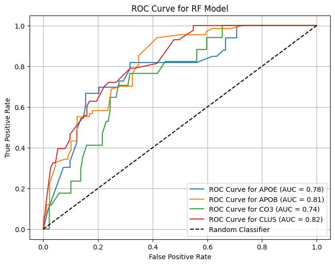

```python
# Final Model Evaluation

plt.figure(figsize=(8, 6))

for target in targets:
    print(f"\nFinal Evaluation for {target}")
    X_test = X_test_full[target]
    y_test = y_test_dict[target]

    # Retrieve the best estimator from results
    best_estimator = results[target]['best_estimator']

    # Predictions and Probabilities
    y_pred = best_estimator.predict(X_test)
    y_prob = best_estimator.predict_proba(X_test)[:, 1]

    # Evaluation Metrics
    acc = accuracy_score(y_test, y_pred)
    roc_auc = roc_auc_score(y_test, y_prob)
    report = classification_report(y_test, y_pred)

    print(f"Accuracy Score: {acc:.4f}")
    print(f"ROC-AUC Score: {roc_auc:.4f}")
    print("Classification Report:\n", report)

    # ROC Curve Plotting
    fpr, tpr, _ = roc_curve(y_test, y_prob)
    plt.plot(fpr, tpr, label=f'ROC Curve for {target} (AUC = {roc_auc:.2f})')

plt.plot([0, 1], [0, 1], 'k--', label='Random Classifier')
plt.title(f'ROC Curve for RF Model')
plt.xlabel('False Positive Rate')
plt.ylabel('True Positive Rate')
plt.legend(loc="lower right")
plt.grid(True)
plt.show()
```

# **4 External Validation and Applicability Domain**

## **4.1 External Validation**

**External validation** refers to the process of assessing the performance of a model using a set of data that was not part of the model's training process. In the context of QSAR (Quantitative Structure-Activity Relationship) modeling or other machine learning models, external validation is used to evaluate how well the model generalizes to new, unseen data that was not included in the training or development of the model.

To assess whether a QSAR model is accurate, demonstrating that it predicts the activity or property of compounds in the training set is not sufficient. Since the model is tailored to the compounds in the training set, it may show excellent performance on this data but perform poorly when applied to new, unseen compounds. External validation refers to the process of testing the original QSAR model on an independent set of compounds to determine whether the model can make reliable predictions for compounds outside the training data. This step ensures that the model generalizes well and performs satisfactorily in real-world scenarios.[4]

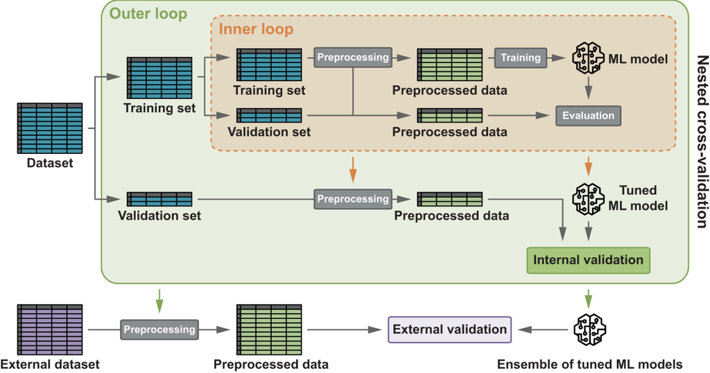

## **4.2 Applicability Domain (AD)**

The **applicability domain(AD)** in machine learning and modeling refers to the region or range of input data for which a model is valid and can make reliable predictions. In other words, it defines the boundaries within which the model is confident in its predictions based on the data it was trained on. If new data falls outside the applicability domain, the model might not be reliable, and its predictions could be uncertain or inaccurate.

In the construction of a QSAR model, the AD of molecules plays a deciding role in estimating the uncertainty in the prediction of a particular compound based on how similar it is to the compounds used to build the model. Therefore, the prediction of a modeled response using QSAR is applicable only if the compound being predicted falls within the AD of the model, as it is impractical to predict an entire universe of chemicals using a single QSAR model. Again, AD can be described as the physicochemical, structural, or biological space information based on which the training set of the model is developed, and the model is applicable to make predictions for new compounds within the specific domain.[6]

In QSAR modeling, AD refers to the specific range or region of chemical space where the model's predictions are reliable. This region is determined by the training set used to develop the model. The prediction accuracy of a QSAR model depends heavily on how similar a new compound is to the compounds that were used to build the model. If a compound lies outside this domain, the model's predictions are more likely to be uncertain or inaccurate because it hasn't encountered similar compounds during training.[7]

**Key points:**

- **Chemical Space:**

The domain is often defined by the physicochemical properties, structural features, or biological activities of the compounds in the training set. These properties might include things like molecular weight, hydrophobicity, functional groups, or electronic properties.

- **Similarity of New Compounds:**

The model will perform well when new compounds are similar to those in the training set (in terms of their chemical or biological characteristics). For example, if the QSAR model is trained to predict the toxicity of a series of compounds with certain structural motifs, its predictions will be most reliable for new compounds that share similar motifs.

- **Distance Measures:**

AD is often quantified using distance-based metrics that assess how far a new compound is from the training set. Common methods include calculating the Euclidean distance between molecular descriptors of the new compound and the training set.[8]

- **Descriptor-Based Boundaries:**

In practice, descriptors like molecular weight, logP, and others can be used to map the chemical space. If a new compound falls outside the established ranges of these descriptors, it may fall outside the AD, making the model’s predictions less trustworthy.[9]

**A common definition** of applicability domain is: the response and chemical structure spaces in which the model makes predictions with a given reliability (boundaries, likelihood, applicability, and reliability). Common methods for applicability domain look at molecular classes, and features, and at agreement in the chemical and response domains; a typical measure of the applicability domain is based on distances within those domains. Exploration of the domain of applicability should answer if a model can be applied to a query compound. Thus, the domain is the model's boundaries.[10]

**William Plot**

**Williams plot** is a widely used graphical tool in quantitative structure–activity relationship (QSAR) modeling and machine learning to assess the applicability domain (AD) of predictive models. It simultaneously visualizes two key metrics for each data point:

- **Leverage** – a measure of the influence of each observation based on its position in the feature space. It reflects how far a sample is from the center of the training data distribution.
- **Standardized residuals** – a measure of prediction error, normalized by the standard deviation of residuals. It highlights how well the model fits each sample.

So, generally speaking, if a data point has a **high leverage (x-axis)**, it means this point is quite different from the training dataset in terms of its input features. In such cases, we cannot confidently guarantee that the model will perform well, as it’s making predictions outside its familiar domain.

On the other hand, the **standardized residuals (y-axis)** reflect how well the model predicted that specific point. A large absolute value means a poor prediction, while values close to zero indicate a good fit.

In the plot, we usually draw:

**One vertical line** to mark the leverage threshold. Points to the right of this line are considered outside the training domain (structurally different), and those on the left are within the domain.

**Two horizontal lines** at ±3 to define the acceptable range of standardized residuals. Predictions within this band are generally considered reliable.

To conclude, we want most of the data points to fall within the central region defined by these lines. That indicates both reliable predictions and that the data are within the model's applicability domain.

For example, look at the graph below:

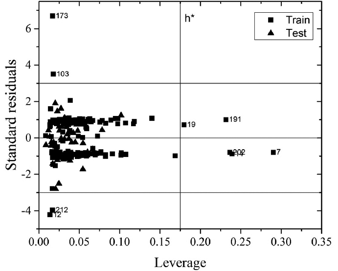

# **5 References**

[1] https://scikit-learn.org/stable/modules/cross_validation.html

[2] https://scikit-learn.org/stable/modules/grid_search.html

[3] https://vitalflux.com/python-nested-cross-validation-algorithm-selection/

[4] Chava L Ramspek, Kitty J Jager, Friedo W Dekker, Carmine Zoccali, Merel van Diepen, External validation of prognostic models: what, why, how, when and where?, Clinical Kidney Journal, Volume 14, Issue 1, January 2021, Pages 49–58, https://doi.org/10.1093/ckj/sfaa188

[5] https://akjournals.com/view/journals/1647/15/1/article-p1.xml (External Validation Figure)

[6] https://www.sciencedirect.com/topics/nursing-and-health-professions/applicability-domain

[7] Ramsay, R. R., & Lee, M. (2012). Applicability domain in QSAR modeling: A review. Journal of Molecular Graphics and Modelling, 38, 89-102.

[8] Araujo, R. M., et al. (2015). Appraising the applicability domain in QSAR: From training to testing and validation. Journal of Chemometrics, 29(4), 276-287.

[9] Vamathevan, J., et al. (2019). Applications of machine learning in drug discovery and development. Nature Reviews Drug Discovery, 18(6), 463-477.

[10] Gabriela Gómez-Jiménez et al. (2018) The OECD principles for (Q)SAR models in the context of knowledge discovery in databases (KDD), Advances in Protein Chemistry and Structural Biology.